# agriGLMflow Tutorial: Complete Modeling Workflows for Agronomic Experiments

From Planning to Inference in English

Author

Walter E. Pereira and Magali H. P. Martinez

Published

September 16, 2026

## Introduction

This tutorial shows, step by step, how to use the `agriGLMflow` package to analyze agronomic experiments. Each section begins with a **domain question**, shows the data before the formulas, and guides the complete analysis through to inference and plots.

**What you will learn:**

- How to correctly declare the experimental design
- How to identify the appropriate distribution family
- How to fit models and compare statistical engines
- How to perform post-model inference (means, contrasts, trends)
- How to generate publication-quality graphs

```r
packageVersion("agriGLMflow")
```

```
#> [1] '0.1.0'
```

```r
R.version.string
```

```
#> [1] "R version 4.6.0 (2026-04-24 ucrt)"
```

## Workflow 1: Qualitative Factor (RCBD with Counts)

### 0.1 Domain Question

> Does a biofertilizer reduce insect infestation in a bean crop? Is the effect consistent across blocks?

### 0.2 1.1 Prepare the Data

```r
# Load insect count data
data("agri_insects", package = "agriGLMflow")

# First rows
head(agri_insects, 10)
```

```
#>    block treatment insects
#> 1      1   Control       8
#> 2      2   Control       3
#> 3      3   Control       1
#> 4      4   Control       4
#> 5      5   Control       9
#> 6      6   Control      10
#> 7      1      BioA       4
#> 8      2      BioA       8
#> 9      3      BioA       5
#> 10     4      BioA       0
```

```r
# Summary by treatment
aggregate(insects ~ treatment, data = agri_insects,
          FUN = function(x) c(mean = mean(x), sd = sd(x), n = length(x)))
```

```
#>   treatment insects.mean insects.sd insects.n
#> 1      BioA     5.333333   4.179314  6.000000
#> 2      BioB     4.833333   6.554896  6.000000
#> 3   Control     5.833333   3.656045  6.000000
#> 4  Standard     3.833333   3.656045  6.000000
```

### 0.3 1.2 Declare the Design

```r
# Create RCBD design object
des <- agri_design(
  data = agri_insects,
  design = "rcbd",
  treatment = treatment,
  block = block
)
print(des)
```

```
#> <agri_design>
#>  Design: rcbd
#>  Treatments: treatment
#>  Blocking: block
#>  Random structure: (1 | `block`)
```

### 0.4 1.3 Characterize the Response

```r
# Characterize the response variable (counts)
resp <- agri_response(
  data = agri_insects,
  response = "insects"
)
print(resp)
```

```
#> <agri_response>
#>  Response: insects
#>  Type: count
#>  N: 24
#>  Mean: 4.9583
#>  Variance: 19.52
#>  Zero fraction: 0.08333
```

### 0.5 1.4 Identify Candidate Families

```r
# Which families are suitable for non-negative integer counts?
cands <- agri_family_candidates(resp, tier = 1L)
print(cands)
```

```
#>  [1] "poisson"          "nbinom1"          "nbinom2"          "compois"
#>  [5] "genpois"          "zip"              "zinb1"            "zinb2"
#>  [9] "hurdle_poisson"   "hurdle_nbinom2"   "vgam_genpoisson1" "vgam_genpoisson2"
#> [13] "vgam_zapoisson"
```

### 0.6 1.5 Fit the Model

```r
# Fit model with auto family (automatic selection)
# The resp object (agri_response) is passed directly
fit <- agri_model(
  data = agri_insects,
  response = resp,
  design = des,
  family = "auto"
)

# Fit summary
summary(fit$engine_fit)
```

[output not shown]

### 0.7 1.6 Diagnostics

```r
# Complete diagnostics
diag <- agri_diagnose(fit)
print(diag)
```

```
#> <agri_diagnostics>
#>  Overall: review
#>  Convergence: acceptable
#>  Dispersion ratio: 1.151
#>  Notes:
#>  - Residual shape warrants review (skewness 1.293; excess kurtosis 1.221).
```

### 0.8 1.7 Post-Model Inference

```r
# Marginal means by treatment
emm <- agri_means(fit, specs = ~ treatment, scale = "response")
print(emm)
```

```
#> <agri_posthoc>
#>  Method: emmeans
#>  treatment response       SE  df asymp.LCL asymp.UCL null z.ratio p.value
#>  BioA      4.821994 1.694371 Inf  2.421744  9.601190    1   4.477 <0.0001
#>  BioB      4.091008 1.475715 Inf  2.017360  8.296161    1   3.905 <0.0001
#>  Control   5.729407 1.860089 Inf  3.032226 10.825745    1   5.377 <0.0001
#>  Standard  3.727090 1.389933 Inf  1.794460  7.741159    1   3.528  0.0004
#>
#> Confidence level used: 0.95
#> Intervals are back-transformed from the log scale
#> Tests are performed on the log scale
```

```r
# Tukey contrasts (pairwise treatment comparisons)
# Note: for glmmTMB Poisson models with block, contrasts
# may require explicit specs
contr <- tryCatch(
  agri_contrasts(fit, specs = ~ treatment, method = "pairwise",
                 adjust = "tukey", scale = "response"),
  error = function(e) {
    cat("Contrasts via emmeans directly:\n")
    emmeans::emmeans(fit$engine_fit, pairwise ~ treatment, type = "response")
  }
)
print(contr)
```

```
#> <agri_posthoc>
#>  Method: pairwise
#>  contrast               ratio        SE  df asymp.LCL asymp.UCL null z.ratio
#>  BioA / BioB        1.1786813 0.5173983 Inf 0.3816255  3.640452    1   0.375
#>  BioA / Control     0.8416219 0.3328315 Inf 0.3047130  2.324573    1  -0.436
#>  BioA / Standard    1.2937692 0.5670882 Inf 0.4195785  3.989334    1   0.588
#>  BioB / Control     0.7140369 0.2973691 Inf 0.2449444  2.081488    1  -0.809
#>  BioB / Standard    1.0976413 0.4980067 Inf 0.3421787  3.521015    1   0.205
#>  Control / Standard 1.5372333 0.6374399 Inf 0.5297721  4.460572    1   1.037
#>  p.value
#>   0.9821
#>   0.9723
#>   0.9359
#>   0.8504
#>   0.9969
#>   0.7277
#>
#> Confidence level used: 0.95
#> Conf-level adjustment: tukey method for comparing a family of 4 estimates
#> Intervals are back-transformed from the log scale
#> P value adjustment: tukey method for comparing a family of 4 estimates
#> Tests are performed on the log scale
```

### 0.9 1.8 Plots

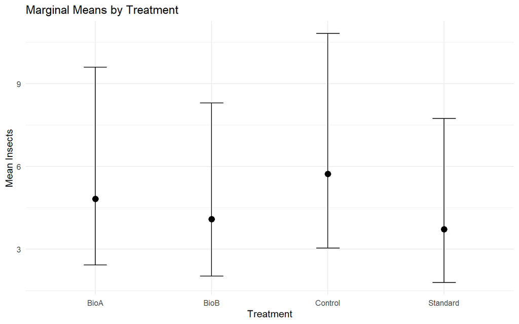

Marginal means by treatment with confidence intervals

```r
# Means plot with ggplot2 directly
library(ggplot2)
emm_df <- emm$table
ggplot(emm_df, aes(x = treatment, y = response)) +
  geom_point(size = 3) +
  geom_errorbar(aes(ymin = asymp.LCL, ymax = asymp.UCL), width = 0.2) +
  labs(x = "Treatment", y = "Mean Insects",
       title = "Marginal Means by Treatment") +
  theme_minimal()
```

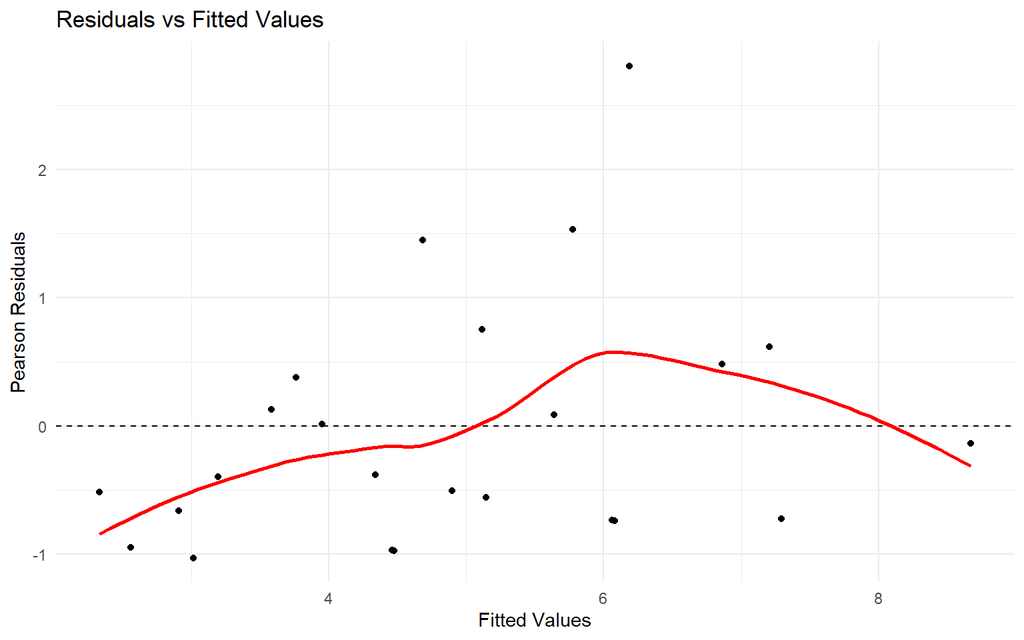

Residual diagnostics

```r
# Residual plot with ggplot2
# For glmmTMB, use fitted() and residuals()
resid_df <- data.frame(
  fitted = fitted(fit$engine_fit),
  residuals = residuals(fit$engine_fit, type = "pearson")
)
ggplot(resid_df, aes(x = fitted, y = residuals)) +
  geom_point() +
  geom_hline(yintercept = 0, linetype = "dashed") +
  geom_smooth(se = FALSE, color = "red") +
  labs(x = "Fitted Values", y = "Pearson Residuals",
       title = "Residuals vs Fitted Values") +
  theme_minimal()
```

## Workflow 2: Quantitative Factor (Dose-Response Regression)

### 0.11 Domain Question

> What is the optimal nitrogen dose that maximizes yield? Does the response follow a quadratic curve with a plateau?

### 0.12 2.1 Prepare the Data

```r
data("agri_dose", package = "agriGLMflow")
head(agri_dose)
```

```
#>   block dose    yield
#> 1     1    0 57.73887
#> 2     2    0 60.88152
#> 3     3    0 58.64342
#> 4     4    0 50.71203
#> 5     5    0 59.54885
#> 6     1   40 72.63928
```

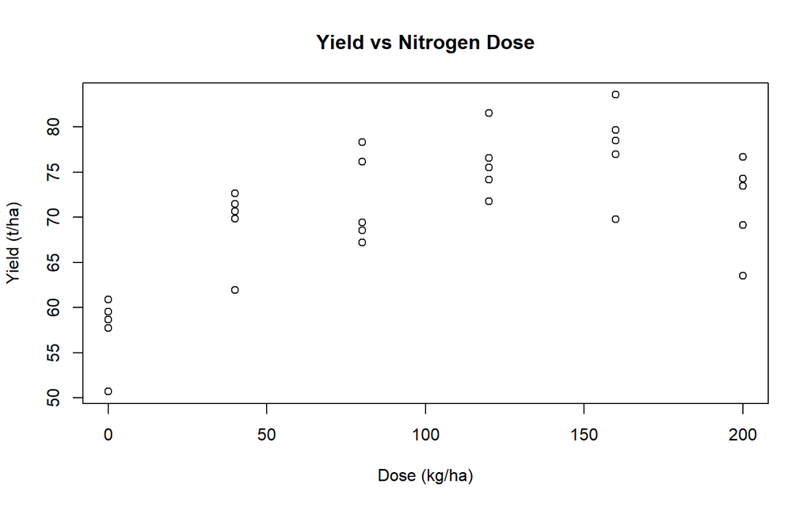

```r
# Exploratory plot
plot(yield ~ dose, data = agri_dose,
     main = "Yield vs Nitrogen Dose",
     xlab = "Dose (kg/ha)", ylab = "Yield (t/ha)")
```

### 0.13 2.2 Fit Regression Models

```r
# Quadratic model
fit_quad <- agri_regression(
  data = agri_dose,
  response = "yield",
  x = "dose",
  model = "quadratic"
)

# Summary with parameters and agronomic targets
print(fit_quad)
```

```
#> <agri_regression>
#>  Model: quadratic
#>  Engine: lm
#>              target  estimate       SE     lower     upper level
#>           x_optimum 133.67954 8.772532 116.48569 150.87338  0.95
#>  x_plateau_response  76.69135 1.169274  74.39961  78.98308  0.95
```

### 0.14 2.3 Compare Models

```r
# Also fit a linear-plateau model
fit_lp <- agri_regression(
  data = agri_dose,
  response = "yield",
  x = "dose",
  model = "linear_plateau"
)

# Compare goodness of fit
# For nls models, check summary structure
cat("Quadratic - fit summary:\n")
```

```
#> Quadratic - fit summary:
```

```r
s_q <- summary(fit_quad$fit)
cat("  R²:", round(s_q$r.squared %||% NA, 4), "\n")
```

```
#>   R²: 0.6902
```

```r
cat("  RMSE:", round(s_q$sigma %||% NA, 4), "\n")
```

```
#>   RMSE: 4.499
```

```r
cat("\nLinear-Plateau - summary:\n")
```

```
#>
#> Linear-Plateau - summary:
```

```r
s_lp <- summary(fit_lp$fit)
cat("  Parameters:\n")
```

```
#>   Parameters:
```

```r
print(coef(s_lp))
```

```
#>      Estimate  Std. Error   t value     Pr(>|t|)
#> a  59.0381408  2.03341372 29.034003 6.740404e-22
#> b   0.1802266  0.03937689  4.576964 9.492053e-05
#> xp 88.5686538 14.64381853  6.048194 1.863512e-06
```

```r
# Show quadratic model parameters
cat("\nQuadratic parameters:\n")
```

```
#>
#> Quadratic parameters:
```

```r
print(coef(fit_quad$fit))
```

```
#>  (Intercept)         dose    I(dose^2)
#> 58.000210051  0.279640985 -0.001045938
```

### 0.15 2.4 Regression Plot

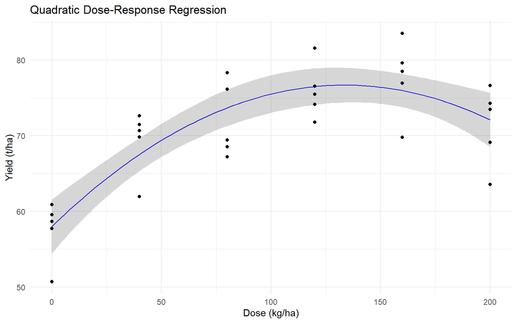

Quadratic regression curve

```r
# Regression plot with ggplot2
newdata <- data.frame(dose = seq(min(agri_dose$dose), max(agri_dose$dose), length.out = 100))
pred <- predict(fit_quad$fit, newdata = newdata, se.fit = TRUE)
newdata$yield_pred <- pred$fit
newdata$yield_se <- pred$se.fit

ggplot(agri_dose, aes(x = dose, y = yield)) +
  geom_point() +
  geom_line(data = newdata, aes(x = dose, y = yield_pred), color = "blue") +
  geom_ribbon(data = newdata, aes(x = dose, ymin = yield_pred - 1.96*yield_se,
                                   ymax = yield_pred + 1.96*yield_se),
              inherit.aes = FALSE, alpha = 0.2) +
  labs(x = "Dose (kg/ha)", y = "Yield (t/ha)",
       title = "Quadratic Dose-Response Regression") +
  theme_minimal()
```

### 0.16 Lesson

> Variables such as dose, time, or rate remain quantitative by default. Do not silently convert them to factors: this loses information and statistical power.

## Workflow 3: Comparing Statistical Engines

### 0.17 Domain Question

> For soil cover proportion data, which statistical engine produces the best fit? Betareg, GAMLSS, or glmmTMB?

### 0.18 3.1 Prepare the Data

```r
data("agri_cover", package = "agriGLMflow")
head(agri_cover)
```

```
#>   block treatment rep     cover
#> 1     1   Control   1 0.0000000
#> 2     2   Control   1 0.6121368
#> 3     3   Control   1 0.5856805
#> 4     4   Control   1 0.0000000
#> 5     5   Control   1 0.7145077
#> 6     6   Control   1 0.8376800
```

```r
# Check proportion limits
range(agri_cover$cover)
```

```
#> [1] 0 1
```

### 0.19 3.2 Fit with Multiple Engines

```r
# Betareg
fit_br <- tryCatch(
  agri_model(data = agri_cover, response = "cover",
             formula = cover ~ treatment, family = "extended_beta",
             engine = "betareg"),
  error = function(e) NULL
)

# glmmTMB beta
fit_tm <- tryCatch(
  agri_model(data = agri_cover, response = "cover",
             formula = cover ~ treatment, family = "beta",
             engine = "glmmTMB"),
  error = function(e) NULL
)

# GAMLSS beta
fit_ga <- tryCatch(
  agri_model(data = agri_cover, response = "cover",
             formula = cover ~ treatment, family = "BEINF",
             engine = "gamlss"),
  error = function(e) NULL
)

# Check which fits were successful
cat("betareg:", !is.null(fit_br), "\n")
```

```
#> betareg: TRUE
```

```r
cat("glmmTMB:", !is.null(fit_tm), "\n")
```

```
#> glmmTMB: FALSE
```

```r
cat("gamlss:", !is.null(fit_ga), "\n")
```

```
#> gamlss: FALSE
```

### 0.20 3.3 Comparative Metrics Table

```r
# Build comparison table
metrics <- data.frame(
  Engine = character(),
  AIC = numeric(),
  logLik = numeric(),
  stringsAsFactors = FALSE
)

if (!is.null(fit_br)) {
  metrics <- rbind(metrics, data.frame(
    Engine = "betareg", AIC = AIC(fit_br$engine_fit),
    logLik = as.numeric(logLik(fit_br$engine_fit))
  ))
}
if (!is.null(fit_tm)) {
  metrics <- rbind(metrics, data.frame(
    Engine = "glmmTMB", AIC = AIC(fit_tm$engine_fit),
    logLik = as.numeric(logLik(fit_tm$engine_fit))
  ))
}
if (!is.null(fit_ga)) {
  metrics <- rbind(metrics, data.frame(
    Engine = "gamlss", AIC = AIC(fit_ga$engine_fit),
    logLik = as.numeric(logLik(fit_ga$engine_fit))
  ))
}

metrics <- metrics[order(metrics$AIC), ]
print(metrics)
```

```
#>    Engine      AIC    logLik
#> 1 betareg 21.99292 -4.996461
```

## Workflow 4: Diagnostics and Sensitivity

### 0.22 Domain Question

> Is the count model adequate? Is there overdispersion or excess zeros?

### 0.23 4.1 Detailed Diagnostics

```r
# Use the fit from Workflow 1
diag <- agri_diagnose(fit, simulate = TRUE, nsim = 100)

# Overall status: the 'overall' field ("acceptable", "review" or "problem")
cat("Overall status:", diag$overall, "\n")
```

```
#> Overall status: review
```

```r
# Diagnostic components
names(diag)
```

```
#>  [1] "overall"     "convergence" "dispersion"  "zeros"       "residuals"
#>  [6] "random"      "influence"   "dependence"  "DHARMa"      "VGAM"
#> [11] "GAMLSS"      "messages"    "model"
```

```r
# Formatted summary
print(diag)
```

```
#> <agri_diagnostics>
#>  Overall: review
#>  Convergence: acceptable
#>  Dispersion ratio: 1.151
#>  Notes:
#>  - Residual shape warrants review (skewness 1.293; excess kurtosis 1.221).
```

### 0.24 4.2 Sensitivity to Alternative Families

```r
# Test alternative families to check robustness
# Note: agri_sensitivity may fail with certain combinations
sens <- tryCatch(
  agri_sensitivity(fit, families = c("poisson", "nbinom2", "nbinom1")),
  error = function(e) {
    cat("Sensitivity not available:", conditionMessage(e), "\n")
    NULL
  }
)
if (!is.null(sens)) print(sens)
```

```
#> <agri_family_scan>
#>  Response type: count
#>  Candidate families: poisson, nbinom2, nbinom1
#>   family  engine             status converged      AIC      BIC    logLik note
#>  poisson glmmTMB diagnostic_problem      TRUE 147.3959 153.2862 -68.69797
#>  nbinom2 glmmTMB         admissible      TRUE 136.7308 143.7991 -62.36539
#>  nbinom1 glmmTMB         admissible      TRUE 136.4279 143.4962 -62.21393
#>  delta_AIC                    role
#>         NA rejected_or_unavailable
#>  0.3029196             recommended
#>  0.0000000             recommended
#>  Recommended: nbinom2, nbinom1
```

### 0.25 4.3 Cross-Validation

```r
# 5-fold cross-validation respecting blocks
cv_result <- agri_cv(fit, v = 5L, unit = "block")
print(cv_result)
```

[output not shown]

[output cut: 32 more lines]

```
#> $unit
#> [1] "block"
#>
#> $seed
#> [1] 123
#>
#> $model
#> <agri_model>
#>  Engine: glmmTMB
#>  Family: nbinom1
#>  Formula: insects ~ treatment + (1 | block)
#>  Converged: yes
#>
#> attr(,"class")
#> [1] "agri_cv"
```

### 0.26 Lesson

> An acceptable diagnostic does not guarantee the best model; it ensures that the model has no evident problems. Always compare with alternative families using prediction metrics.

## Closing

### 0.27 Complete Package Workflow

```
graph TD
    A[Raw data] --> B[agri_design]
    B --> C[agri_response]
    C --> D[agri_family_scan]
    D --> E[agri_model]
    E --> F[agri_diagnose]
    F --> G[agri_means / agri_contrasts]
    G --> H[agri_plot_*]
    E --> I[agri_regression]
    I --> J[agri_compare_curves]
    F --> K[agri_cv / agri_bootstrap]
    E --> L[agri_report]
```

[output not shown]

### 0.28 Best Practice Rules

1. **Declare the design before fitting**: the experimental unit determines the variance structure.
2. **Do not p-hack**: model selection should be based on predefined criteria (AIC, BIC, cross-validation), not on significance.
3. **Always check residuals**: convergence is not sufficient.
4. **Record decisions**: use `agri_audit()` to track what was done and why.
5. **Use fixed seeds**: reproducibility is essential for science.

### 0.29 Exercises

**Exercise 1 (Basic Level)**

Fit a Poisson model to the `agri_disease` data using `agri_glm()`. Compare the results with a direct call to `glm()`.

```r
# Your answer here
```

**Exercise 2 (Intermediate Level)**

For the `agri_germination` data, fit a binomial model with `agri_glm()` and another with `agri_model(family = "auto")`. Compare the estimates.

```r
# Your answer here
```

**Exercise 3 (Advanced Level)**

Use `agri_workflow()` to analyze the `agri_splitplot` data as a split-plot design. Verify that the package correctly detected the main-plot structure.

```r
# Your answer here
```

### 0.30 How to Cite

```r
citation("agriGLMflow")
```

```
#>
#>   Development Team a (2026). _agriGLMflow: Unified Generalized, Mixed
#>   and Distributional Modelling Workflows for Agricultural Experiments_.
#>   R package version 0.1.0.
#>
#> A BibTeX entry for LaTeX users is
#>
#>   @Manual{,
#>     title = {agriGLMflow: Unified Generalized, Mixed and Distributional Modelling Workflows for Agricultural Experiments},
#>     author = {agriGLMflow {Development Team}},
#>     year = {2026},
#>     note = {R package version 0.1.0},
#>   }
```

```r
packageVersion("agriGLMflow")
```

```
#> [1] '0.1.0'
```

```r
R.version.string
```

```
#> [1] "R version 4.6.0 (2026-04-24 ucrt)"
```